# dog_app

## Convolutional Neural Networks

## Project: Write an Algorithm for a Dog Identification App

In this notebook, some template code has already been provided for you, and you will need to implement additional functionality to successfully complete this project. You will not need to modify the included code beyond what is requested. Sections that begin with **'(IMPLEMENTATION)'** in the header indicate that the following block of code will require additional functionality which you must provide. Instructions will be provided for each section, and the specifics of the implementation are marked in the code block with a 'TODO' statement. Please be sure to read the instructions carefully!

In addition to implementing code, there will be questions that you must answer which relate to the project and your implementation. Each section where you will answer a question is preceded by a **'Question X'** header. Carefully read each question and provide thorough answers in the following text boxes that begin with **'Answer:'**. Your project submission will be evaluated based on your answers to each of the questions and the implementation you provide.

> **Note:** Code and Markdown cells can be executed using the **Shift + Enter** keyboard shortcut. Markdown cells can be edited by double-clicking the cell to enter edit mode.

The rubric contains *optional* "Stand Out Suggestions" for enhancing the project beyond the minimum requirements. If you decide to pursue the "Stand Out Suggestions", you should include the code in this IPython notebook.

### Why We're Here

In this notebook, you will make the first steps towards developing an algorithm that could be used as part of a mobile or web app. At the end of this project, your code will accept any user-supplied image as input. If a dog is detected in the image, it will provide an estimate of the dog's breed. If a human is detected, it will provide an estimate of the dog breed that is most resembling. The image below displays potential sample output of your finished project (... but we expect that each student's algorithm will behave differently!).

[figure not shown]

In this real-world setting, you will need to piece together a series of models to perform different tasks; for instance, the algorithm that detects humans in an image will be different from the CNN that infers dog breed. There are many points of possible failure, and no perfect algorithm exists. Your imperfect solution will nonetheless create a fun user experience!

### The Road Ahead

We break the notebook into separate steps. Feel free to use the links below to navigate the notebook.

- Step 0: Import Datasets
- Step 1: Detect Humans
- Step 2: Detect Dogs
- Step 3: Create a CNN to Classify Dog Breeds (from Scratch)
- Step 4: Use a CNN to Classify Dog Breeds (using Transfer Learning)
- Step 5: Create a CNN to Classify Dog Breeds (using Transfer Learning)
- Step 6: Write your Algorithm
- Step 7: Test Your Algorithm

## Step 0: Import Datasets

### Import Dog Dataset

In the code cell below, we import a dataset of dog images. We populate a few variables through the use of the `load_files` function from the scikit-learn library:

- `train_files`, `valid_files`, `test_files` - numpy arrays containing file paths to images
- `train_targets`, `valid_targets`, `test_targets` - numpy arrays containing onehot-encoded classification labels
- `dog_names` - list of string-valued dog breed names for translating labels

```python
from sklearn.datasets import load_files
from keras.utils import np_utils
import numpy as np
from glob import glob

# define function to load train, test, and validation datasets
def load_dataset(path):
    data = load_files(path)
    dog_files = np.array(data['filenames'])
    dog_targets = np_utils.to_categorical(np.array(data['target']), 133)
    return dog_files, dog_targets

# load train, test, and validation datasets
train_files, train_targets = load_dataset('/data/dog_images/train')
valid_files, valid_targets = load_dataset('/data/dog_images/valid')
test_files, test_targets = load_dataset('/data/dog_images/test')

# load list of dog names
dog_names = [item[20:-1] for item in sorted(glob("/data/dog_images/train/*/"))]

# print statistics about the dataset
print('There are %d total dog categories.' % len(dog_names))
print('There are %s total dog images.\n' % len(np.hstack([train_files, valid_files, test_files])))
print('There are %d training dog images.' % len(train_files))
print('There are %d validation dog images.' % len(valid_files))
print('There are %d test dog images.'% len(test_files))
```

```
There are 133 total dog categories.
There are 8351 total dog images.

There are 6680 training dog images.
There are 835 validation dog images.
There are 836 test dog images.
```

```python
#what is the shape of the train data for example
print('train_targets shape: ', train_targets.shape)
```

```
train_targets shape:  (6680, 133)
```

```python
print('train_files shape : ',train_files.shape)

# check data format
train_files[0]
```

```
train_files shape :  (6680,)
```

```
'/data/dog_images/train/095.Kuvasz/Kuvasz_06442.jpg'
```

### Import Human Dataset

In the code cell below, we import a dataset of human images, where the file paths are stored in the numpy array `human_files`.

```python
import random
random.seed(8675309)

# load filenames in shuffled human dataset
human_files = np.array(glob("/data/lfw/*/*"))
random.shuffle(human_files)

# print statistics about the dataset
print('There are %d total human images.' % len(human_files))
```

```
There are 13233 total human images.
```

```python
print('human_files shape:', human_files.shape)
#check data format
human_files[0]
```

```
human_files shape: (13233,)
```

```
'/data/lfw/Rick_Dinse/Rick_Dinse_0002.jpg'
```

## Step 1: Detect Humans

We use OpenCV's implementation of [Haar feature-based cascade classifiers](http://docs.opencv.org/trunk/d7/d8b/tutorial_py_face_detection.html) to detect human faces in images. OpenCV provides many pre-trained face detectors, stored as XML files on [github](https://github.com/opencv/opencv/tree/master/data/haarcascades). We have downloaded one of these detectors and stored it in the `haarcascades` directory.

In the next code cell, we demonstrate how to use this detector to find human faces in a sample image.

```
Number of faces detected: 1
```

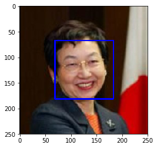

```python
import cv2
import matplotlib.pyplot as plt
%matplotlib inline

# extract pre-trained face detector
face_cascade = cv2.CascadeClassifier('haarcascades/haarcascade_frontalface_alt.xml')

# load color (BGR) image
#img = cv2.imread('images/flowers.jpg')
img = cv2.imread(human_files[8659])
# convert BGR image to grayscale
gray = cv2.cvtColor(img, cv2.COLOR_BGR2GRAY)

# find faces in image
faces = face_cascade.detectMultiScale(gray)

# print number of faces detected in the image
print('Number of faces detected:', len(faces))

# get bounding box for each detected face
for (x,y,w,h) in faces:
    # add bounding box to color image
    cv2.rectangle(img,(x,y),(x+w,y+h),(255,0,0),2)

# convert BGR image to RGB for plotting
cv_rgb = cv2.cvtColor(img, cv2.COLOR_BGR2RGB)

# display the image, along with bounding box
plt.imshow(cv_rgb)
plt.show()
```

Before using any of the face detectors, it is standard procedure to convert the images to grayscale. The `detectMultiScale` function executes the classifier stored in `face_cascade` and takes the grayscale image as a parameter.

In the above code, `faces` is a numpy array of detected faces, where each row corresponds to a detected face. Each detected face is a 1D array with four entries that specifies the bounding box of the detected face. The first two entries in the array (extracted in the above code as `x` and `y`) specify the horizontal and vertical positions of the top left corner of the bounding box. The last two entries in the array (extracted here as `w` and `h`) specify the width and height of the box.

### Write a Human Face Detector

We can use this procedure to write a function that returns `True` if a human face is detected in an image and `False` otherwise. This function, aptly named `face_detector`, takes a string-valued file path to an image as input and appears in the code block below.

```python
# returns "True" if face is detected in image stored at img_path
def face_detector(img_path):
    img = cv2.imread(img_path)
    gray = cv2.cvtColor(img, cv2.COLOR_BGR2GRAY)
    faces = face_cascade.detectMultiScale(gray)
    return len(faces) > 0
```

### (IMPLEMENTATION) Assess the Human Face Detector

**Question 1:** Use the code cell below to test the performance of the `face_detector` function.

- What percentage of the first 100 images in `human_files` have a detected human face?
- What percentage of the first 100 images in `dog_files` have a detected human face?

Ideally, we would like 100% of human images with a detected face and 0% of dog images with a detected face. You will see that our algorithm falls short of this goal, but still gives acceptable performance. We extract the file paths for the first 100 images from each of the datasets and store them in the numpy arrays `human_files_short` and `dog_files_short`.

**Answer:**

```python
human_files_short = human_files[:100]
dog_files_short = train_files[:100]
# Do NOT modify the code above this line.
```

```python
## TODO: Test the performance of the face_detector algorithm
## on the images in human_files_short and dog_files_short.

human_faces = 0
for image_path in human_files_short:
    human_faces += face_detector(image_path)

print("accuracy of detecting human faces is {} %".format(human_faces))


dog_faces = 0
for image_path in dog_files_short:
    dog_faces += face_detector(image_path)

print("accuracy of detecting dog faces is {} %".format(dog_faces))
```

```
accuracy of detecting human faces is 100 %
accuracy of detecting dog faces is 11 %
```

**Question 2:** This algorithmic choice necessitates that we communicate to the user that we accept human images only when they provide a clear view of a face (otherwise, we risk having unneccessarily frustrated users!). In your opinion, is this a reasonable expectation to pose on the user? If not, can you think of a way to detect humans in images that does not necessitate an image with a clearly presented face?

**Answer:** I think it is very reasonable to communicate for the user the limitation of the software, that they need to have their face looking front, not sideways or updown ways. The task of detecting humans in images may not be an easy task. Of course, one should try to find ways to overcome the current limitations. One way to do it is to use images where humans are present and label them as human, and another set of images where humans are not present and label them as other. Furhter more, one would have to make the decision, in the choice of human images in the training set, whether to allow ones with mix of human and animals or other objects in the images. Then, after choosing a dataset, we design a CNN or use as below a pretrained model such as ResNet50 for the convolution layers and then follow this with fully connected layers.**end of answer**

We suggest the face detector from OpenCV as a potential way to detect human images in your algorithm, but you are free to explore other approaches, especially approaches that make use of deep learning :). Please use the code cell below to design and test your own face detection algorithm. If you decide to pursue this *optional* task, report performance on each of the datasets.

```python
## (Optional) TODO: Report the performance of another
## face detection algorithm on the LFW dataset
### Feel free to use as many code cells as needed.
```

First, I start with an attempt to use openCV to improve on `face_detector` function above. I continue to use the same Haar cascade classifier for frontal orientated face, but now I adjust the scale parameter and number of neighbors parameters. I kept tuning these two parameters till I got a good compromise minimizing false negatives and false positives.

```python
# returns "True" if face is detected in image stored at img_path
def face_detector_cv2(img_path):
    img = cv2.imread(img_path)
    gray = cv2.cvtColor(img, cv2.COLOR_BGR2GRAY)
    faces = face_cascade.detectMultiScale(gray, 1.05, 12)
    return len(faces) > 0
```

```python
total_faces = 0
for face in human_files[3000:4000]:
    total_faces += face_detector_cv2(face)

print('human face detectioin accuracy : ',total_faces/1000)
```

```
human face detectioin accuracy :  0.964
```

```python
#dog_files_short = train_files[0:100]
total_dogs = 0
for face in dog_files_short:
    total_dogs += face_detector_cv2(face)

print('False positive rate of dog faces dected as human face : {0:.4f}'.format(total_dogs/len(test_files)))
```

```
False positive rate of dog faces dected as human face : 0.0036
```

### Data preparation

I intend to use deep learning starting first with my own convolutional neural network and then I will use `ResNet50`. But first, I need to create a dataset. For simplicity I will use the given human files representing `human` and dog files representing `other`. Aiming for a balaced dataset, I subdivide the human files similar to the already available dog files train, validation and test dataset sizes.

My goal is to look for an algorithm that detect human faces 100% and dogs 0%. In other words, no false positives or false negatives.

```python
# data preparation shuffle human files more before extracting
# train, validation and test sets.

import random

for i in range(0,10):
    random.shuffle(human_files)

L = len(train_files)
M = L + len(valid_files)
K = M + len(test_files)
human_train = human_files[0:L]
human_valid = human_files[L:M]
human_test = human_files[M:K]

len(human_train)
```

```
6680
```

```python
# stack human and dog files for train, validation and test datasets

human_dog_train = np.hstack((human_train, train_files))
len(human_dog_train)

human_dog_valid = np.hstack((human_valid, valid_files))
len(human_dog_valid)

human_dog_test = np.hstack((human_test, test_files))
len(human_dog_test)
```

```
1672
```

```python
# create binary targets, set human to zero and dog to one so that
# np_unil.to_categorical sets first column for human
human_dog_train_target =np.hstack((np.zeros((L,),dtype=int),np.ones((L,),dtype=int)))
human_dog_valid_target =np.hstack((np.zeros((len(valid_files),),dtype=int),np.ones((len(valid_files),),dtype=int)))
human_dog_test_target =np.hstack((np.zeros((len(test_files),),dtype=int),np.ones((len(test_files),),dtype=int)))
sum(human_dog_valid_target)
```

```
835
```

```python
human_dog_train_target.shape
```

```
(13360,)
```

```python
# hot-one-encoder setting the first column for human and second for dog
human_dog_train_targets = np_utils.to_categorical(np.array(human_dog_train_target), 2)
human_dog_valid_targets = np_utils.to_categorical(np.array(human_dog_valid_target), 2)
human_dog_test_targets = np_utils.to_categorical(np.array(human_dog_test_target), 2)
```

```python
human_dog_test_targets[830:840,:]
```

```
array([[ 1.,  0.],
       [ 1.,  0.],
       [ 1.,  0.],
       [ 1.,  0.],
       [ 1.,  0.],
       [ 1.,  0.],
       [ 0.,  1.],
       [ 0.,  1.],
       [ 0.,  1.],
       [ 0.,  1.]])
```

I copy some of the functions that are used in the next sections to prepare and process image data.

```python
# Now we want to load the images and write them into tensors
# I borrow the code from the section 2 below
from keras.preprocessing import image
from tqdm import tqdm

def path_to_tensor(img_path):
    # loads RGB image as PIL.Image.Image type
    img = image.load_img(img_path, target_size=(224, 224))
    # convert PIL.Image.Image type to 3D tensor with shape (224, 224, 3)
    x = image.img_to_array(img)
    # convert 3D tensor to 4D tensor with shape (1, 224, 224, 3) and return 4D tensor
    return np.expand_dims(x, axis=0)

def paths_to_tensor(img_paths):
    list_of_tensors = [path_to_tensor(img_path) for img_path in tqdm(img_paths)]
    return np.vstack(list_of_tensors)
```

```python
from PIL import ImageFile
ImageFile.LOAD_TRUNCATED_IMAGES = True

# pre-process the data for Keras
HD_train_tensors = paths_to_tensor(human_dog_train).astype('float32')/255
HD_valid_tensors = paths_to_tensor(human_dog_valid).astype('float32')/255
HD_test_tensors = paths_to_tensor(human_dog_test).astype('float32')/255
```

```python
HD_train_tensors.shape
```

```
(13360, 224, 224, 3)
```

```python
## Now we use deeplearning on these images
## my cnn architecture

from keras.models import Sequential
from keras.layers import Dense, Flatten, Conv2D, MaxPool2D, Dropout
from keras.layers import GlobalAveragePooling2D

HD_model = Sequential()
HD_model.add(Conv2D(filters = 16, kernel_size = 2 , strides = 1, activation = 'relu', input_shape = (224, 224, 3)))
HD_model.add(MaxPool2D(pool_size =2))
HD_model.add(Conv2D(filters = 32, kernel_size = 2, strides = 1, activation ='relu'))
HD_model.add(MaxPool2D(pool_size =2))
HD_model.add(Conv2D(filters = 64, kernel_size = 2, strides = 1, activation ='relu'))
HD_model.add(MaxPool2D(pool_size =2))
HD_model.add(GlobalAveragePooling2D())
HD_model.add(Dropout(0.3))
HD_model.add(Dense(256, activation = 'relu'))
HD_model.add(Dropout(0.4))
HD_model.add(Dense(2, activation = 'softmax'))

HD_model.summary()
```

```
_________________________________________________________________
Layer (type)                 Output Shape              Param #
=================================================================
conv2d_1 (Conv2D)            (None, 223, 223, 16)      208
_________________________________________________________________
max_pooling2d_1 (MaxPooling2 (None, 111, 111, 16)      0
_________________________________________________________________
conv2d_2 (Conv2D)            (None, 110, 110, 32)      2080
_________________________________________________________________
max_pooling2d_2 (MaxPooling2 (None, 55, 55, 32)        0
_________________________________________________________________
conv2d_3 (Conv2D)            (None, 54, 54, 64)        8256
_________________________________________________________________
max_pooling2d_3 (MaxPooling2 (None, 27, 27, 64)        0
_________________________________________________________________
global_average_pooling2d_1 ( (None, 64)                0
_________________________________________________________________
dropout_1 (Dropout)          (None, 64)                0
_________________________________________________________________
dense_1 (Dense)              (None, 256)               16640
_________________________________________________________________
dropout_2 (Dropout)          (None, 256)               0
_________________________________________________________________
dense_2 (Dense)              (None, 2)                 514
=================================================================
Total params: 27,698
Trainable params: 27,698
Non-trainable params: 0
_________________________________________________________________
```

```python
HD_model.compile(optimizer='rmsprop', loss='categorical_crossentropy', metrics=['accuracy'])
```

```python
from keras.callbacks import ModelCheckpoint

checkpointer = ModelCheckpoint(filepath='saved_models/HD_weights.best.from_scratch.hdf5',
                               verbose=1, save_best_only=True)

epochs = 30
HD_model.fit(HD_train_tensors, human_dog_train_targets,
          validation_data=(HD_valid_tensors, human_dog_valid_targets),
          epochs=epochs, batch_size=20, callbacks=[checkpointer], verbose=1)
```

```
Train on 13360 samples, validate on 1670 samples
```

```
<keras.callbacks.History at 0x7f0370099518>
```

```python
HD_model.load_weights('saved_models/HD_weights.best.from_scratch.hdf5')
```

```python
# get index of predicted dog breed for each image in test set
human_dog_predictions = [np.argmax(HD_model.predict(np.expand_dims(tensor, axis=0))) for tensor in HD_test_tensors]

# report test accuracy
test_accuracy = 100*np.sum(np.array(human_dog_predictions)==np.argmax(human_dog_test_targets, axis=1))/len(human_dog_predictions)
print('Test accuracy: %.4f%%' % test_accuracy)
```

```
Test accuracy: 98.2656%
```

Even though I get good accuracy and the data is rather balanced, It is a good idea to look for the ability of the algorithm to detect true positives and true negatives. We do this below by constructing a detector that uses the results of the above algorithm.

```python
def human_face_simple_detector(img_path):
    # prepare image to run model prediction
    img = path_to_tensor(img_path)
    # use model to predict human or dog
    pred = np.argmax(HD_model.predict(img))
    # return True if human
    return (pred == 0)
```

```python
# testing the algorithm on human_files_short and dog_files_short
human_faces = 0
for image_path in human_files_short:
    human_faces += human_face_simple_detector(image_path)

print("human faces detected using human_files_short: accuracy is {}%".format(human_faces))

dog_faces = 0
for image_path in dog_files_short:
    human_faces += human_face_simple_detector(image_path)

print("dog faces detected using dog_files_short: accuracy is {}%".format(dog_faces))
```

```
human faces detected using human_files_short: accuracy is 77%
dog faces detected using dog_files_short: accuracy is 0%
```

Repeating the above test on another slice of the dataset:

```python
human_faces = 0
for image_path in human_files[12300:13300]:
    human_faces += human_face_simple_detector(image_path)
```

```python
print('human faces : ', human_faces/len(human_files[12300:13300]))
```

```
human faces :  0.736334405145
```

```python
dog_faces = 0
for image_path in test_files:
    dog_faces += human_face_simple_detector(image_path)

print('dogs detected : ', dog_faces/len(test_files))
```

```
dogs detected :  0.0622009569378
```

Next, I retry the above model on augmented data, just in case it may offer some imporvements.

```python
from keras.preprocessing.image import ImageDataGenerator

# create and configure augmented image generator
datagen_train = ImageDataGenerator(
    width_shift_range=0.1,  # randomly shift images horizontally (10% of total width)
    height_shift_range=0.1,  # randomly shift images vertically (10% of total height)
    rotation_range = 20, #randomly rotate images by 20 degrees.
    horizontal_flip=True) # randomly flip images horizontally

# create and configure augmented image generator
datagen_valid = ImageDataGenerator(
    width_shift_range=0.1,  # randomly shift images horizontally (10% of total width)
    height_shift_range=0.1,  # randomly shift images vertically (10% of total height)
    horizontal_flip=True) # randomly flip images horizontally

# fit augmented image generator on data
datagen_train.fit(HD_train_tensors)
datagen_valid.fit(HD_valid_tensors)
```

```python
from keras.callbacks import ModelCheckpoint
batch_size = 20
epochs = 20

# train the model
checkpointer = ModelCheckpoint(filepath='saved_models/HD_aug_model_best_weights_from_scratch.hdf5', verbose=1,
                               save_best_only=True)
HD_model.fit_generator(datagen_train.flow(HD_train_tensors, human_dog_train_targets, batch_size=batch_size),
                    steps_per_epoch=HD_train_tensors.shape[0] // batch_size,
                    epochs=epochs, verbose=2, callbacks=[checkpointer],
                    validation_data=datagen_valid.flow(HD_valid_tensors, human_dog_valid_targets, batch_size=batch_size),
                    validation_steps=HD_valid_tensors.shape[0] // batch_size)
```

```
Epoch 00001: val_loss improved from inf to 0.08719, saving model to saved_models/HD_aug_model_best_weights_from_scratch.hdf5
 - 122s - loss: 0.1058 - acc: 0.9674 - val_loss: 0.0872 - val_acc: 0.9723
Epoch 00002: val_loss improved from 0.08719 to 0.08175, saving model to saved_models/HD_aug_model_best_weights_from_scratch.hdf5
 - 121s - loss: 0.1057 - acc: 0.9679 - val_loss: 0.0818 - val_acc: 0.9789
Epoch 00003: val_loss did not improve
 - 121s - loss: 0.0989 - acc: 0.9708 - val_loss: 0.0821 - val_acc: 0.9759
Epoch 00004: val_loss did not improve
 - 120s - loss: 0.1023 - acc: 0.9700 - val_loss: 0.0909 - val_acc: 0.9729
Epoch 00005: val_loss did not improve
 - 119s - loss: 0.0984 - acc: 0.9711 - val_loss: 0.2997 - val_acc: 0.9133
Epoch 00006: val_loss did not improve
 - 119s - loss: 0.0926 - acc: 0.9714 - val_loss: 0.3285 - val_acc: 0.9211
Epoch 00007: val_loss improved from 0.08175 to 0.07885, saving model to saved_models/HD_aug_model_best_weights_from_scratch.hdf5
 - 122s - loss: 0.1095 - acc: 0.9688 - val_loss: 0.0788 - val_acc: 0.9807
Epoch 00008: val_loss did not improve
 - 121s - loss: 0.0993 - acc: 0.9723 - val_loss: 0.6729 - val_acc: 0.8229
Epoch 00009: val_loss did not improve
 - 120s - loss: 0.0929 - acc: 0.9709 - val_loss: 0.1005 - val_acc: 0.9705
Epoch 00010: val_loss improved from 0.07885 to 0.07092, saving model to saved_models/HD_aug_model_best_weights_from_scratch.hdf5
 - 122s - loss: 0.0951 - acc: 0.9696 - val_loss: 0.0709 - val_acc: 0.9837
Epoch 00011: val_loss did not improve
 - 122s - loss: 0.1056 - acc: 0.9686 - val_loss: 0.1036 - val_acc: 0.9681
Epoch 00012: val_loss improved from 0.07092 to 0.06354, saving model to saved_models/HD_aug_model_best_weights_from_scratch.hdf5
 - 122s - loss: 0.1017 - acc: 0.9722 - val_loss: 0.0635 - val_acc: 0.9819
Epoch 00013: val_loss did not improve
 - 122s - loss: 0.0993 - acc: 0.9707 - val_loss: 0.1288 - val_acc: 0.9675
Epoch 00014: val_loss did not improve
 - 121s - loss: 0.1034 - acc: 0.9723 - val_loss: 0.0653 - val_acc: 0.9825
Epoch 00015: val_loss improved from 0.06354 to 0.06319, saving model to saved_models/HD_aug_model_best_weights_from_scratch.hdf5
 - 121s - loss: 0.1035 - acc: 0.9692 - val_loss: 0.0632 - val_acc: 0.9837
Epoch 00016: val_loss did not improve
 - 119s - loss: 0.1041 - acc: 0.9718 - val_loss: 0.0897 - val_acc: 0.9771
Epoch 00017: val_loss did not improve
 - 119s - loss: 0.1013 - acc: 0.9737 - val_loss: 0.0690 - val_acc: 0.9831
Epoch 00018: val_loss did not improve
 - 119s - loss: 0.1099 - acc: 0.9694 - val_loss: 0.1759 - val_acc: 0.9488
Epoch 00019: val_loss did not improve
 - 119s - loss: 0.0985 - acc: 0.9721 - val_loss: 0.1069 - val_acc: 0.9633
Epoch 00020: val_loss did not improve
 - 119s - loss: 0.1003 - acc: 0.9709 - val_loss: 0.1026 - val_acc: 0.9705
```

```
<keras.callbacks.History at 0x7f5f9c65e320>
```

```python
HD_model.load_weights('saved_models/HD_aug_model_best_weights_from_scratch.hdf5')
```

```python
# get index of predicted dog breed for each image in test set
human_dog_predictions = [np.argmax(HD_model.predict(np.expand_dims(tensor, axis=0))) for tensor in HD_test_tensors]

# report test accuracy
test_accuracy = 100*np.sum(np.array(human_dog_predictions)==np.argmax(human_dog_test_targets, axis=1))/len(human_dog_predictions)
print('Test accuracy: %.4f%%' % test_accuracy)
```

```
Test accuracy: 98.2057%
```

Again a detector using the model is necessary as explained above.

```python
def human_face_aug_detector(img_path):
    img = path_to_tensor(img_path)
    pred = np.argmax(HD_model.predict(img))
    return (pred == 0)
```

```python
human_faces = 0
for image_path in human_files_short:
    human_faces += human_face_aug_detector(image_path)

print('humanc face detection accuracy: {} %'.format(human_faces))

dog_faces = 0
for image_path in dog_files_short:
    dog_faces += human_face_aug_detector(image_path)

print('dog face detection accuracy: {} %'.format(dog_faces))
```

```
humanc face detection accuracy: 84 %
dog face detection accuracy: 3 %
```

```python
human_faces = 0
for image_path in human_files[12000:12900]:
    human_faces += human_face_aug_detector(image_path)

print('accuracy of human face detection :', human_faces/len(human_files[12000:12900]))
```

```
accuracy of human face detection : 0.755555555556
```

```python
dog_faces = 0
for image_path in test_files:
    dog_faces += human_face_aug_detector(image_path)

print('dogs detected : ', dog_faces/len(test_files))
```

```
dogs detected :  0.0311004784689
```

Slight imporvement is welcome but not satisfactory. Probably I should modify the architecture. However, I would rather try out transer learning.

Applying **transfer learning** in what follows we use **ResNet50**, to improve on the previous simpler detector. In fact, when I did the computations below, I got worse results than my detector. Thus, I tried again with **InceptionV3** and got similar resultst to ResNet50, So I concluded that these are not suitable for binary classification of my dataset.

```python
from keras.applications.resnet50 import ResNet50, preprocess_input
HD_resnet_model = ResNet50(weights='imagenet', include_top = False)
```

```
Downloading data from https://github.com/fchollet/deep-learning-models/releases/download/v0.2/resnet50_weights_tf_dim_ordering_tf_kernels_notop.h5
```

```python
from keras.applications.inception_v3 import InceptionV3, preprocess_input
HD_inception_model = InceptionV3(include_top = False, weights='imagenet')
```

```
Downloading data from https://github.com/fchollet/deep-learning-models/releases/download/v0.5/inception_v3_weights_tf_dim_ordering_tf_kernels_notop.h5
```

```python
def get_bottleneck_features(model, tensors, dataset_type):
    model_input = preprocess_input(tensors)
    features = model.predict(model_input)
    #features = np.squeeze(features)
    #np.savez('HD_resnet50_'+dataset_type, features)
    return features
```

```python
#Bottleneck features of ResNet50 for train, validation and test datasets

resnet_input_train = get_bottleneck_features(HD_resnet_model, HD_train_tensors, 'train')
resnet_input_valid = get_bottleneck_features(HD_resnet_model, HD_valid_tensors, 'valid')
resnet_input_test = get_bottleneck_features(HD_resnet_model, HD_test_tensors, 'test')
```

```python
#bottleneck features of InceptionV3 for train, validation and test datasets
inception_input_train = get_bottleneck_features(HD_inception_model, HD_train_tensors, 'train')
inception_input_valid = get_bottleneck_features(HD_inception_model, HD_valid_tensors, 'valid')
inception_input_test = get_bottleneck_features(HD_inception_model, HD_test_tensors, 'test')
```

```python
#check shape of training set
print(resnet_input_train.shape[1:])
```

```
(1, 1, 2048)
```

```python
# Transfer learning from ResNet50 algorithm
# adding three fully connected layers
HD_2_model = Sequential()
HD_2_model.add(GlobalAveragePooling2D(input_shape=resnet_input_train.shape[1:]))
HD_2_model.add(Dense(512, activation = 'relu'))
HD_2_model.add(Dropout(0.3))
HD_2_model.add(Dense(64, activation = 'relu'))
HD_2_model.add(Dropout(0.3))
HD_2_model.add(Dense(2, activation='softmax'))


HD_2_model.summary()
```

```
_________________________________________________________________
Layer (type)                 Output Shape              Param #
=================================================================
global_average_pooling2d_2 ( (None, 2048)              0
_________________________________________________________________
dense_3 (Dense)              (None, 512)               1049088
_________________________________________________________________
dropout_3 (Dropout)          (None, 512)               0
_________________________________________________________________
dense_4 (Dense)              (None, 64)                32832
_________________________________________________________________
dropout_4 (Dropout)          (None, 64)                0
_________________________________________________________________
dense_5 (Dense)              (None, 2)                 130
=================================================================
Total params: 1,082,050
Trainable params: 1,082,050
Non-trainable params: 0
_________________________________________________________________
```

```python
# Transfer learning from InceptionV3 algorithm
# adding one fully connected layer
HD_3_model = Sequential()
HD_3_model.add(GlobalAveragePooling2D(input_shape=inception_input_train.shape[1:]))
HD_3_model.add(Dense(2, activation='softmax'))

HD_3_model.summary()
```

```
_________________________________________________________________
Layer (type)                 Output Shape              Param #
=================================================================
global_average_pooling2d_3 ( (None, 2048)              0
_________________________________________________________________
dense_6 (Dense)              (None, 2)                 4098
=================================================================
Total params: 4,098
Trainable params: 4,098
Non-trainable params: 0
_________________________________________________________________
```

**Compiling models 2 and 3**

```python
HD_2_model.compile(loss='categorical_crossentropy', optimizer='rmsprop', metrics=['accuracy'])
```

```python
HD_3_model.compile(loss='categorical_crossentropy', optimizer='rmsprop', metrics=['accuracy'])
```

**Model training**

```python
# training ResNet50 model
from keras.callbacks import ModelCheckpoint

checkpointer = ModelCheckpoint(filepath='saved_models/HD_resnet_weights.best.hdf5',
                               verbose=1, save_best_only=True)

HD_2_model.fit(resnet_input_train, human_dog_train_targets,
          validation_data=(resnet_input_valid, human_dog_valid_targets),
          epochs=50, batch_size=20, callbacks=[checkpointer], verbose=1)
```

```
Train on 13360 samples, validate on 1670 samples
```

```
<keras.callbacks.History at 0x7f4fe1a15668>
```

```python
#training InceptionV3 model

from keras.callbacks import ModelCheckpoint

checkpointer = ModelCheckpoint(filepath='saved_models/HD_inception_weights.best.hdf5',
                               verbose=1, save_best_only=True)

HD_3_model.fit(inception_input_train, human_dog_train_targets,
          validation_data=(inception_input_valid, human_dog_valid_targets),
          epochs=30, batch_size=20, callbacks=[checkpointer], verbose=1)
```

```
Train on 13360 samples, validate on 1670 samples
```

```
<keras.callbacks.History at 0x7f618d55e518>
```

**Loading best weights**

```python
HD_2_model.load_weights('saved_models/HD_resnet_weights.best.hdf5')
```

```python
HD_3_model.load_weights('saved_models/HD_inception_weights.best.hdf5')
```

**Testing accuracy**

```python
# get index of predicted dog breed for each image in test set
human_dog_predictions = [np.argmax(HD_2_model.predict(np.expand_dims(tensor, axis=0))) for tensor in resnet_input_test]

# report test accuracy
test_accuracy = 100*np.sum(np.array(human_dog_predictions)==np.argmax(human_dog_test_targets, axis=1))/len(human_dog_predictions)
print('Test accuracy: %.4f%%' % test_accuracy)
```

```
Test accuracy: 50.0000%
```

```python
# get index of predicted dog breed for each image in test set
human_dog_predictions_3 = [np.argmax(HD_3_model.predict(np.expand_dims(tensor, axis=0))) for tensor in inception_input_test]

# report test accuracy
test_accuracy = 100*np.sum(np.array(human_dog_predictions_3)==np.argmax(human_dog_test_targets, axis=1))/len(human_dog_predictions_3)
print('Test accuracy: %.4f%%' % test_accuracy)
```

```
Test accuracy: 50.0000%
```

```python
human_dog_test_targets.shape
np.argmax(human_dog_test_targets, axis=1)[900:920]
print('human face prediction accuracy : ', 1-sum(human_dog_predictions[0:836])/836)
print('dog prediction accuracy:',sum(human_dog_predictions[836:])/836)
```

```
human face prediction accuracy :  0.0
dog prediction accuracy: 1.0
```

```python
len(human_dog_predictions)
human_dog_predictions[0:10]
HD_2_model.predict(np.expand_dims(resnet_input_test[1], axis=0))
human_dog_test_targets[1]
human_dog_test[1]
#np.argmax(HD_2_model.predict(np.expand_dims(resnet_input_test[1], axis=0)))
```

```
'/data/lfw/Patrick_Leahy/Patrick_Leahy_0001.jpg'
```

```python
# preparing data for simple detector
HD_detector_test_tensors = paths_to_tensor(human_files[12000:13000]).astype('float32')/255
```

```python
HD_detector_test_tensors.shape
```

```
(1000, 224, 224, 3)
```

```python
#extracting bottleneck feattures
resnet_input_test_2 = get_bottleneck_features(HD_resnet_model, HD_detector_test_tensors,'test')
inception_input_test_2 = get_bottleneck_features(HD_inception_model, HD_detector_test_tensors,'test')
```

```python
def human_resnet_detector_2(processed_img):
    pred = np.argmax(HD_2_model.predict(np.expand_dims(processed_img, axis=0)))
    return (pred == 0)
```

```python
def human_inception_detector_2(processed_img):
    pred = np.argmax(HD_3_model.predict(np.expand_dims(processed_img, axis=0)))
    return (pred == 0)
```

```python
resnet_input_test_2.shape
```

```
(1000, 1, 1, 2048)
```

```python
total =0
for processed_img in resnet_input_test_2:
    total += human_resnet_detector_2(processed_img)

print('ResNet50 human detector accuracy: ', total/len(resnet_input_test_2) )
```

```
ResNet50 human detector accuracy:  0.0
```

```python
tatol =0
for processed_img in inception_input_test_2:
    total += human_inception_detector_2(processed_img)

print('InceptionV3 human detector accuracy: ', total/len(inception_input_test_2) )
```

```
InceptionV3 human detector accuracy:  0.0
```

#### Discussion of optional human face detector

In the above we find that the transfer learning from pretrained architectures are not suitable for this binary classification problem. Could it be the dataset? However, we found that the simpler convolution neural network had performed better that transfer learning. Using augmented images with first CNN also improved the detection, however, it seems that I need to work on the architecture, but I am not sure what should I focus on. Should add another convolution layer, increase or decrease the number of filter per convolution layer, have less or more fully connected layers. These are all possibilities that I would consider.

## Step 2: Detect Dogs

In this section, we use a pre-trained [ResNet-50](http://ethereon.github.io/netscope/#/gist/db945b393d40bfa26006) model to detect dogs in images. Our first line of code downloads the ResNet-50 model, along with weights that have been trained on [ImageNet](http://www.image-net.org/), a very large, very popular dataset used for image classification and other vision tasks. ImageNet contains over 10 million URLs, each linking to an image containing an object from one of [1000 categories](https://gist.github.com/yrevar/942d3a0ac09ec9e5eb3a). Given an image, this pre-trained ResNet-50 model returns a prediction (derived from the available categories in ImageNet) for the object that is contained in the image.

```python
from keras.applications.resnet50 import ResNet50

# define ResNet50 model
ResNet50_model = ResNet50(weights='imagenet')
```

```
Downloading data from https://github.com/fchollet/deep-learning-models/releases/download/v0.2/resnet50_weights_tf_dim_ordering_tf_kernels.h5
```

### Pre-process the Data

When using TensorFlow as backend, Keras CNNs require a 4D array (which we'll also refer to as a 4D tensor) as input, with shape

$$ (\text{nb_samples}, \text{rows}, \text{columns}, \text{channels}), $$

where `nb_samples` corresponds to the total number of images (or samples), and `rows`, `columns`, and `channels` correspond to the number of rows, columns, and channels for each image, respectively.

The `path_to_tensor` function below takes a string-valued file path to a color image as input and returns a 4D tensor suitable for supplying to a Keras CNN. The function first loads the image and resizes it to a square image that is $224 \times 224$ pixels. Next, the image is converted to an array, which is then resized to a 4D tensor. In this case, since we are working with color images, each image has three channels. Likewise, since we are processing a single image (or sample), the returned tensor will always have shape

$$ (1, 224, 224, 3). $$

The `paths_to_tensor` function takes a numpy array of string-valued image paths as input and returns a 4D tensor with shape

$$ (\text{nb_samples}, 224, 224, 3). $$

Here, `nb_samples` is the number of samples, or number of images, in the supplied array of image paths. It is best to think of `nb_samples` as the number of 3D tensors (where each 3D tensor corresponds to a different image) in your dataset!

```python
from keras.preprocessing import image
from tqdm import tqdm

def path_to_tensor(img_path):
    # loads RGB image as PIL.Image.Image type
    img = image.load_img(img_path, target_size=(224, 224))
    # convert PIL.Image.Image type to 3D tensor with shape (224, 224, 3)
    x = image.img_to_array(img)
    # convert 3D tensor to 4D tensor with shape (1, 224, 224, 3) and return 4D tensor
    return np.expand_dims(x, axis=0)

def paths_to_tensor(img_paths):
    list_of_tensors = [path_to_tensor(img_path) for img_path in tqdm(img_paths)]
    return np.vstack(list_of_tensors)
```

### Making Predictions with ResNet-50

Getting the 4D tensor ready for ResNet-50, and for any other pre-trained model in Keras, requires some additional processing. First, the RGB image is converted to BGR by reordering the channels. All pre-trained models have the additional normalization step that the mean pixel (expressed in RGB as $[103.939, 116.779, 123.68]$ and calculated from all pixels in all images in ImageNet) must be subtracted from every pixel in each image. This is implemented in the imported function `preprocess_input`. If you're curious, you can check the code for `preprocess_input` [here](https://github.com/fchollet/keras/blob/master/keras/applications/imagenet_utils.py).

Now that we have a way to format our image for supplying to ResNet-50, we are now ready to use the model to extract the predictions. This is accomplished with the `predict` method, which returns an array whose $i$-th entry is the model's predicted probability that the image belongs to the $i$-th ImageNet category. This is implemented in the `ResNet50_predict_labels` function below.

By taking the argmax of the predicted probability vector, we obtain an integer corresponding to the model's predicted object class, which we can identify with an object category through the use of this [dictionary](https://gist.github.com/yrevar/942d3a0ac09ec9e5eb3a).

```python
from keras.applications.resnet50 import preprocess_input, decode_predictions

img = preprocess_input(path_to_tensor(train_files[1]))
pred = ResNet50_model.predict(img)
pred.shape
decode_pred = decode_predictions(pred, top=3)
print(type(decode_pred))
print('Predicted:', decode_predictions(pred, top=1)[0])
print(np.argmax(pred))
```

```
Downloading data from https://s3.amazonaws.com/deep-learning-models/image-models/imagenet_class_index.json
<class 'list'>
Predicted: [('n02110341', 'dalmatian', 0.99971229)]
251
```

```python
img = preprocess_input(path_to_tensor(human_files[1]))
pred = ResNet50_model.predict(img)
print('Predicted:', decode_predictions(pred, top=3)[0])
print(np.argmax(pred))
```

```
Predicted: [('n03877472', 'pajama', 0.070495203), ('n03814639', 'neck_brace', 0.068676353), ('n03630383', 'lab_coat', 0.043921396)]
697
```

```python
from keras.applications.resnet50 import preprocess_input, decode_predictions

def ResNet50_predict_labels(img_path):
    # returns prediction vector for image located at img_path
    img = preprocess_input(path_to_tensor(img_path))
    return np.argmax(ResNet50_model.predict(img))
```

### Write a Dog Detector

While looking at the [dictionary](https://gist.github.com/yrevar/942d3a0ac09ec9e5eb3a), you will notice that the categories corresponding to dogs appear in an uninterrupted sequence and correspond to dictionary keys 151-268, inclusive, to include all categories from `'Chihuahua'` to `'Mexican hairless'`. Thus, in order to check to see if an image is predicted to contain a dog by the pre-trained ResNet-50 model, we need only check if the `ResNet50_predict_labels` function above returns a value between 151 and 268 (inclusive).

We use these ideas to complete the `dog_detector` function below, which returns `True` if a dog is detected in an image (and `False` if not).

```python
### returns "True" if a dog is detected in the image stored at img_path
def dog_detector(img_path):
    prediction = ResNet50_predict_labels(img_path)
    return ((prediction <= 268) & (prediction >= 151))
```

```python
total = 0
for face in dog_files_short:
    total += dog_detector(face)

print('percent of dogs detected in short dataset is: ',total)
```

```
percent of dogs detected in short dataset is:  100
```

```python
total = 0
for face in test_files:
    total += dog_detector(face)

print('precent dogs detected in test dataset is: ',total/len(test_files))
```

```
precent dogs detected in test dataset is:  0.982057416268
```

### (IMPLEMENTATION) Assess the Dog Detector

**Question 3:** Use the code cell below to test the performance of your `dog_detector` function.

- What percentage of the images in `human_files_short` have a detected dog?
- What percentage of the images in `dog_files_short` have a detected dog?

**Answer:**

```python
### TODO: Test the performance of the dog_detector function
### on the images in human_files_short and dog_files_short.
sum = 0
for image_path in dog_files_short:
    sum += dog_detector(image_path)

print("accuracy of dog_detector in dog_images is {} %".format(sum))

sum = 0
for image_path in human_files_short:
    sum += dog_detector(image_path)

print("accuracy of dog_detector in human_images is {} %".format(sum))
```

```
accuracy of dog_detector in dog_images is 100 %
accuracy of dog_detector in human_images is 1 %
```

## Step 3: Create a CNN to Classify Dog Breeds (from Scratch)

Now that we have functions for detecting humans and dogs in images, we need a way to predict breed from images. In this step, you will create a CNN that classifies dog breeds. You must create your CNN *from scratch* (so, you can't use transfer learning *yet*!), and you must attain a test accuracy of at least 1%. In Step 5 of this notebook, you will have the opportunity to use transfer learning to create a CNN that attains greatly improved accuracy.

Be careful with adding too many trainable layers! More parameters means longer training, which means you are more likely to need a GPU to accelerate the training process. Thankfully, Keras provides a handy estimate of the time that each epoch is likely to take; you can extrapolate this estimate to figure out how long it will take for your algorithm to train.

We mention that the task of assigning breed to dogs from images is considered exceptionally challenging. To see why, consider that *even a human* would have great difficulty in distinguishing between a Brittany and a Welsh Springer Spaniel.

| Brittany | Welsh Springer Spaniel |
| --- | --- |

It is not difficult to find other dog breed pairs with minimal inter-class variation (for instance, Curly-Coated Retrievers and American Water Spaniels).

| Curly-Coated Retriever | American Water Spaniel |
| --- | --- |

Likewise, recall that labradors come in yellow, chocolate, and black. Your vision-based algorithm will have to conquer this high intra-class variation to determine how to classify all of these different shades as the same breed.

| Yellow Labrador | Chocolate Labrador | Black Labrador |
| --- | --- | --- |

We also mention that random chance presents an exceptionally low bar: setting aside the fact that the classes are slightly imabalanced, a random guess will provide a correct answer roughly 1 in 133 times, which corresponds to an accuracy of less than 1%.

Remember that the practice is far ahead of the theory in deep learning. Experiment with many different architectures, and trust your intuition. And, of course, have fun!

### Pre-process the Data

We rescale the images by dividing every pixel in every image by 255.

```python
from PIL import ImageFile
ImageFile.LOAD_TRUNCATED_IMAGES = True

# pre-process the data for Keras
train_tensors = paths_to_tensor(train_files).astype('float32')/255
valid_tensors = paths_to_tensor(valid_files).astype('float32')/255
test_tensors = paths_to_tensor(test_files).astype('float32')/255
```

```python
train_tensors.shape
```

```
(6680, 224, 224, 3)
```

### (IMPLEMENTATION) Model Architecture

Create a CNN to classify dog breed. At the end of your code cell block, summarize the layers of your model by executing the line:

```
    model.summary()
```

We have imported some Python modules to get you started, but feel free to import as many modules as you need. If you end up getting stuck, here's a hint that specifies a model that trains relatively fast on CPU and attains >1% test accuracy in 5 epochs:

[figure not shown]

**Question 4:** Outline the steps you took to get to your final CNN architecture and your reasoning at each step. If you chose to use the hinted architecture above, describe why you think that CNN architecture should work well for the image classification task.

**Answer:** Since we are classfying images, we would use convolution layers in the deep learning algorithm to account for two dimensional local information for each pixel. I also wanted to have pooling layer, since pooling reduces complexity and overfitting, I used max pooling for simplicity. My first model is very similar in structure to the one given ubove. However, I found that having two convolution layers and then followed by max pooling works best for this data. In total I started with three blocks of such a sequence (convolution, convolution, max pooling) following by Global Average Pooling layer, which is prefered over flatten layer as we prepare to hand things over to a fully connected layer. Global Average pooling, reduces each filter to a single value, and so it also reduces complexity tremendasouly and it seems that is trains well and speeds learning as a result.

The first reviewer encouraged me to consider Batch Normalization to reduce "internal covariate shift", which results from the internal operation such as convolution, pooling and activation. Now activation that I used is rectified linear units ReLU that is an identity for poitive input and zeros out any negative input. So the main increase in scale or shift to hight values is due convolution and max pooling. The batch normalization layer works on one batch at a time normalizing the input so that the parameters have mean zero and unit variation. I noticed two effects of having batch normalization sandwishing convolution layers as well as pooling layes. for one, it speeds up the training process, so there is considerable improvement from one epoch to the next. Second, as a result of speed in training and learning, I got better accuracy on testing data in fewer training epoch runs.

I included two fully connected layers seperated with a Dropout layer to reduce overfitting. Why did I include two fully connected layers? I do not know, but asking my sel this question I ran the model with two dense layers versus one dense layer at the end. I found that if I have three blocks of "convolution, convolution, pooling" then one dense layer is better. However, when I have four blocks then it appears have the two dense layers is prefered.

I also played with kernel size, comparing kernel size of 3 and kernel size of 5. Both with stride 1.

Test accuracy using **one dense layer**

| kernel size | 3 blocks | 4 blocks |
| --- | --- | --- |
| 3 by 3 | 22.49 | 33.85 |
| 5 by 5 | 34.33 | 32.3 |

Test accuracy using **two dense layers** (Dense layer, Dropout layer, Dense layer)

| kernel size | 3 blocks | 4 blocks |
| --- | --- | --- |
| 3 by 3 | 20.45 | 36.84 |
| 5 by 5 | 25.71 | x |

I did not do the 5 by 5 kernels and using two dense layers since the number of parameters to train is over 1 million and so the requires more time for training.

The above exercise gives a sense that the deeper model prefers smaller kernel size but requires more than one fully connected layer at the end. This could be due to some information is lost so we get underfitting and the extra dense layer corrects for this. On the other hand, for not so deep having three blocks, one dense layer is sufficient and works better with larger kernel size. Notice that kernal size of 5 means we take into account a wider view of central pixel neighbors. Knowing that the first convolution layers account for crude information or simple features we may not need a kernel of size 5, but size 3 is sufficient. So it would be interesting to have the first tow blocks kernels of size 3 and last two blocks kernels of size 5.

Earlier, using the three blocks model with two dense layers at the top(end), I considered having 3 convolution layers followed by max pooling, but the results was not encourageing. However, I would consider repeating this, using one dense layer and kernel size 5.

```python
from keras.layers import Conv2D, MaxPooling2D, GlobalAveragePooling2D
from keras.layers import Dropout, Flatten, Dense, BatchNormalization
from keras.models import Sequential

model = Sequential()

### TODO: Define your architecture.
model.add(Conv2D(filters = 16, kernel_size = 5, strides = 1, padding='same', activation = 'relu', input_shape = (224,224,3)))
model.add(BatchNormalization())
model.add(Conv2D(filters = 16, kernel_size = 5, strides = 1, padding='same', activation = 'relu'))
model.add(BatchNormalization())
model.add(MaxPooling2D(pool_size = 2))
model.add(BatchNormalization())
model.add(Conv2D(filters = 32, kernel_size = 5, strides = 1, padding='same', activation = 'relu'))
model.add(BatchNormalization())
model.add(Conv2D(filters = 32, kernel_size = 5, strides = 1, padding='same', activation = 'relu'))
model.add(BatchNormalization())
model.add(MaxPooling2D(pool_size = 2))
model.add(Conv2D(filters = 64, kernel_size = 5, strides = 1, padding = 'same', activation = 'relu'))
model.add(BatchNormalization())
model.add(Conv2D(filters = 64, kernel_size = 5, strides = 1, padding = 'same', activation = 'relu'))
model.add(BatchNormalization())
model.add(MaxPooling2D(pool_size = 2))
model.add(BatchNormalization())
model.add(GlobalAveragePooling2D())
model.add(BatchNormalization())
model.add(Dense(256, activation = 'relu'))
model.add(Dropout(0.3))
model.add(Dense(133, activation = 'softmax'))

model.summary()
```

```
_________________________________________________________________
Layer (type)                 Output Shape              Param #
=================================================================
conv2d_7 (Conv2D)            (None, 224, 224, 16)      1216
_________________________________________________________________
batch_normalization_10 (Batc (None, 224, 224, 16)      64
_________________________________________________________________
conv2d_8 (Conv2D)            (None, 224, 224, 16)      6416
_________________________________________________________________
batch_normalization_11 (Batc (None, 224, 224, 16)      64
_________________________________________________________________
max_pooling2d_4 (MaxPooling2 (None, 112, 112, 16)      0
_________________________________________________________________
batch_normalization_12 (Batc (None, 112, 112, 16)      64
_________________________________________________________________
conv2d_9 (Conv2D)            (None, 112, 112, 32)      12832
_________________________________________________________________
batch_normalization_13 (Batc (None, 112, 112, 32)      128
_________________________________________________________________
conv2d_10 (Conv2D)           (None, 112, 112, 32)      25632
_________________________________________________________________
batch_normalization_14 (Batc (None, 112, 112, 32)      128
_________________________________________________________________
max_pooling2d_5 (MaxPooling2 (None, 56, 56, 32)        0
_________________________________________________________________
conv2d_11 (Conv2D)           (None, 56, 56, 64)        51264
_________________________________________________________________
batch_normalization_15 (Batc (None, 56, 56, 64)        256
_________________________________________________________________
conv2d_12 (Conv2D)           (None, 56, 56, 64)        102464
_________________________________________________________________
batch_normalization_16 (Batc (None, 56, 56, 64)        256
_________________________________________________________________
max_pooling2d_6 (MaxPooling2 (None, 28, 28, 64)        0
_________________________________________________________________
batch_normalization_17 (Batc (None, 28, 28, 64)        256
_________________________________________________________________
global_average_pooling2d_2 ( (None, 64)                0
_________________________________________________________________
batch_normalization_18 (Batc (None, 64)                256
_________________________________________________________________
dense_3 (Dense)              (None, 256)               16640
_________________________________________________________________
dropout_2 (Dropout)          (None, 256)               0
_________________________________________________________________
dense_4 (Dense)              (None, 133)               34181
=================================================================
Total params: 252,117
Trainable params: 251,381
Non-trainable params: 736
_________________________________________________________________
```

```python
from keras.layers import Conv2D, MaxPooling2D, GlobalAveragePooling2D
from keras.layers import Dropout, Flatten, Dense, BatchNormalization
from keras.models import Sequential

model = Sequential()

### TODO: Define your architecture.
model.add(Conv2D(filters = 16, kernel_size = 5, strides = 1, padding='same', activation = 'relu', input_shape = (224,224,3)))
model.add(BatchNormalization())
model.add(Conv2D(filters = 16, kernel_size = 5, strides = 1, padding='same', activation = 'relu'))
model.add(BatchNormalization())
model.add(MaxPooling2D(pool_size = 2))
model.add(BatchNormalization())
model.add(Conv2D(filters = 32, kernel_size = 5, strides = 1, padding='same', activation = 'relu'))
model.add(BatchNormalization())
model.add(Conv2D(filters = 32, kernel_size = 5, strides = 1, padding='same', activation = 'relu'))
model.add(BatchNormalization())
model.add(MaxPooling2D(pool_size = 2))
model.add(Conv2D(filters = 64, kernel_size = 5, strides = 1, padding = 'same', activation = 'relu'))
model.add(BatchNormalization())
model.add(Conv2D(filters = 64, kernel_size = 5, strides = 1, padding = 'same', activation = 'relu'))
model.add(BatchNormalization())
model.add(MaxPooling2D(pool_size = 2))
model.add(BatchNormalization())
model.add(GlobalAveragePooling2D())
model.add(BatchNormalization())
#model.add(Flatten())
#model.add(Dense(256, activation = 'relu'))
#model.add(Dropout(0.3))
model.add(Dense(133, activation = 'softmax'))

model.summary()
```

```
_________________________________________________________________
Layer (type)                 Output Shape              Param #
=================================================================
conv2d_19 (Conv2D)           (None, 224, 224, 16)      1216
_________________________________________________________________
batch_normalization_26 (Batc (None, 224, 224, 16)      64
_________________________________________________________________
conv2d_20 (Conv2D)           (None, 224, 224, 16)      6416
_________________________________________________________________
batch_normalization_27 (Batc (None, 224, 224, 16)      64
_________________________________________________________________
max_pooling2d_11 (MaxPooling (None, 112, 112, 16)      0
_________________________________________________________________
batch_normalization_28 (Batc (None, 112, 112, 16)      64
_________________________________________________________________
conv2d_21 (Conv2D)           (None, 112, 112, 32)      12832
_________________________________________________________________
batch_normalization_29 (Batc (None, 112, 112, 32)      128
_________________________________________________________________
conv2d_22 (Conv2D)           (None, 112, 112, 32)      25632
_________________________________________________________________
batch_normalization_30 (Batc (None, 112, 112, 32)      128
_________________________________________________________________
max_pooling2d_12 (MaxPooling (None, 56, 56, 32)        0
_________________________________________________________________
conv2d_23 (Conv2D)           (None, 56, 56, 64)        51264
_________________________________________________________________
batch_normalization_31 (Batc (None, 56, 56, 64)        256
_________________________________________________________________
conv2d_24 (Conv2D)           (None, 56, 56, 64)        102464
_________________________________________________________________
batch_normalization_32 (Batc (None, 56, 56, 64)        256
_________________________________________________________________
max_pooling2d_13 (MaxPooling (None, 28, 28, 64)        0
_________________________________________________________________
batch_normalization_33 (Batc (None, 28, 28, 64)        256
_________________________________________________________________
global_average_pooling2d_3 ( (None, 64)                0
_________________________________________________________________
batch_normalization_34 (Batc (None, 64)                256
_________________________________________________________________
dense_3 (Dense)              (None, 133)               8645
=================================================================
Total params: 209,941
Trainable params: 209,205
Non-trainable params: 736
_________________________________________________________________
```

### Compile the Model

```python
model.compile(optimizer='rmsprop', loss='categorical_crossentropy', metrics=['accuracy'])
```

### (IMPLEMENTATION) Train the Model

Train your model in the code cell below. Use model checkpointing to save the model that attains the best validation loss.

You are welcome to [augment the training data](https://blog.keras.io/building-powerful-image-classification-models-using-very-little-data.html), but this is not a requirement.

```python
from keras.callbacks import ModelCheckpoint, EarlyStopping

### TODO: specify the number of epochs that you would like to use to train the model.

epochs = 50

### Do NOT modify the code below this line.
earlystopping = EarlyStopping(monitor='val_loss', min_delta=0, patience=5, verbose=1, mode='min')

#checkpointer = ModelCheckpoint(filepath='saved_models/weights.best.from_scratch.hdf5',
#                               verbose=1, save_best_only=True)
#checkpointer = ModelCheckpoint(filepath='saved_models/weights.best.from_scratch_expt_kernel3.hdf5',
#                               verbose=1, save_best_only=True)
#checkpointer = ModelCheckpoint(filepath='saved_models/weights.best.from_scratch_expt_dense.hdf5',
#                               verbose=1, save_best_only=True)

checkpointer = ModelCheckpoint(filepath='saved_models/weights.best.from_scratch_expt_dense_k5.hdf5',
                               verbose=1, save_best_only=True)

model.fit(train_tensors, train_targets,
          validation_data=(valid_tensors, valid_targets),
          epochs=epochs, batch_size=20, callbacks=[checkpointer,earlystopping], verbose=1)
```

```
Train on 6680 samples, validate on 835 samples
Epoch 00031: early stopping
```

```
<keras.callbacks.History at 0x7f3a95da9a58>
```

### Load the Model with the Best Validation Loss

```python
#model.load_weights('saved_models/weights.best.from_scratch.hdf5') # two dense layers kernel size 5
#model.load_weights('saved_models/weights.best.from_scratch_expt_kernel3.hdf5') # two dense layers kernel size 3
#model.load_weights('saved_models/weights.best.from_scratch_expt_dense.hdf5') # one dense layer kernel size 3
model.load_weights('saved_models/weights.best.from_scratch_expt_dense_k5.hdf5') #one dense layer kernel size 5
```

### Test the Model

Try out your model on the test dataset of dog images. Ensure that your test accuracy is greater than 1%.

```python
test_targets.shape
test_target[0]
```

```python
# get index of predicted dog breed for each image in test set
dog_breed_predictions = [np.argmax(model.predict(np.expand_dims(tensor, axis=0))) for tensor in test_tensors]

# report test accuracy
test_accuracy = 100*np.sum(np.array(dog_breed_predictions)==np.argmax(test_targets, axis=1))/len(dog_breed_predictions)
print('Test accuracy: %.4f%%' % test_accuracy)
```

```
Test accuracy: 34.3301%
```

### Modified deeper model

**Four blocks** of (convolution, BN, convolution, BN, max pooling, BN)

where BN stands for batch normalization layers

```python
from keras.layers import Conv2D, MaxPooling2D, GlobalAveragePooling2D
from keras.layers import Dropout, Flatten, Dense, BatchNormalization
from keras.models import Sequential

model = Sequential()

### TODO: Define your architecture.
model.add(Conv2D(filters = 16, kernel_size = 5, strides = 1, padding='same', activation = 'relu', input_shape = (224,224,3)))
model.add(BatchNormalization())
model.add(Conv2D(filters = 16, kernel_size = 5, strides = 1, padding='same', activation = 'relu'))
model.add(BatchNormalization())
model.add(MaxPooling2D(pool_size = 2))
model.add(BatchNormalization())
model.add(Conv2D(filters = 32, kernel_size = 5, strides = 1, padding='same', activation = 'relu'))
model.add(BatchNormalization())
model.add(Conv2D(filters = 32, kernel_size = 5, strides = 1, padding='same', activation = 'relu'))
model.add(BatchNormalization())
model.add(MaxPooling2D(pool_size = 2))
model.add(Conv2D(filters = 64, kernel_size = 5, strides = 1, padding = 'same', activation = 'relu'))
model.add(BatchNormalization())
model.add(Conv2D(filters = 128, kernel_size = 5, strides = 1, padding = 'same', activation = 'relu'))
model.add(BatchNormalization())
model.add(MaxPooling2D(pool_size = 2))
model.add(Conv2D(filters = 128, kernel_size = 5, strides = 1, padding = 'same', activation = 'relu'))
model.add(BatchNormalization())
model.add(Conv2D(filters = 128, kernel_size = 5, strides = 1, padding = 'same', activation = 'relu'))
model.add(BatchNormalization())
model.add(MaxPooling2D(pool_size = 2))
model.add(BatchNormalization())
model.add(GlobalAveragePooling2D())
model.add(BatchNormalization())
#model.add(Flatten())
#model.add(Dense(256, activation = 'relu'))
#model.add(Dropout(0.3))
model.add(Dense(133, activation = 'softmax'))

model.summary()
```

```
_________________________________________________________________
Layer (type)                 Output Shape              Param #
=================================================================
conv2d_57 (Conv2D)           (None, 224, 224, 16)      1216
_________________________________________________________________
batch_normalization_79 (Batc (None, 224, 224, 16)      64
_________________________________________________________________
conv2d_58 (Conv2D)           (None, 224, 224, 16)      6416
_________________________________________________________________
batch_normalization_80 (Batc (None, 224, 224, 16)      64
_________________________________________________________________
max_pooling2d_30 (MaxPooling (None, 112, 112, 16)      0
_________________________________________________________________
batch_normalization_81 (Batc (None, 112, 112, 16)      64
_________________________________________________________________
conv2d_59 (Conv2D)           (None, 112, 112, 32)      12832
_________________________________________________________________
batch_normalization_82 (Batc (None, 112, 112, 32)      128
_________________________________________________________________
conv2d_60 (Conv2D)           (None, 112, 112, 32)      25632
_________________________________________________________________
batch_normalization_83 (Batc (None, 112, 112, 32)      128
_________________________________________________________________
max_pooling2d_31 (MaxPooling (None, 56, 56, 32)        0
_________________________________________________________________
conv2d_61 (Conv2D)           (None, 56, 56, 64)        51264
_________________________________________________________________
batch_normalization_84 (Batc (None, 56, 56, 64)        256
_________________________________________________________________
conv2d_62 (Conv2D)           (None, 56, 56, 128)       204928
_________________________________________________________________
batch_normalization_85 (Batc (None, 56, 56, 128)       512
_________________________________________________________________
max_pooling2d_32 (MaxPooling (None, 28, 28, 128)       0
_________________________________________________________________
conv2d_63 (Conv2D)           (None, 28, 28, 128)       409728
_________________________________________________________________
batch_normalization_86 (Batc (None, 28, 28, 128)       512
_________________________________________________________________
conv2d_64 (Conv2D)           (None, 28, 28, 128)       409728
_________________________________________________________________
batch_normalization_87 (Batc (None, 28, 28, 128)       512
_________________________________________________________________
max_pooling2d_33 (MaxPooling (None, 14, 14, 128)       0
_________________________________________________________________
batch_normalization_88 (Batc (None, 14, 14, 128)       512
_________________________________________________________________
global_average_pooling2d_8 ( (None, 128)               0
_________________________________________________________________
batch_normalization_89 (Batc (None, 128)               512
_________________________________________________________________
dense_9 (Dense)              (None, 133)               17157
=================================================================
Total params: 1,142,165
Trainable params: 1,140,533
Non-trainable params: 1,632
_________________________________________________________________
```

```python
model.compile(optimizer='rmsprop', loss='categorical_crossentropy', metrics=['accuracy'])
```

```python
from keras.callbacks import ModelCheckpoint, EarlyStopping

### TODO: specify the number of epochs that you would like to use to train the model.

epochs = 50

### Do NOT modify the code below this line.
earlystopping = EarlyStopping(monitor='val_loss', min_delta=0, patience=5, verbose=1, mode='min')

#checkpointer = ModelCheckpoint(filepath='saved_models/weights.best.from_scratch_2.hdf5',
#                               verbose=1, save_best_only=True)

checkpointer = ModelCheckpoint(filepath='saved_models/weights.best.from_scratch_2_exp_dense_k5.hdf5',
                               verbose=1, save_best_only=True)

model.fit(train_tensors, train_targets,
          validation_data=(valid_tensors, valid_targets),
          epochs=epochs, batch_size=32, callbacks=[checkpointer,earlystopping], verbose=1)
```

```
Train on 6680 samples, validate on 835 samples
Epoch 00022: early stopping
```

```
<keras.callbacks.History at 0x7f3a78a3aa58>
```

```python
model.load_weights('saved_models/weights.best.from_scratch_2.hdf5') #model weights for kernel size 3, two dense layers
#model.load_weights('saved_models/weights.best.from_scratch_2_exp_dense_k3.hdf5') # kernal size 3, one dense layer
#model.load_weights('saved_models/weights.best.from_scratch_2_exp_dense_k5.hdf5') # kernel size 5, one dense layer
```

```python
# get index of predicted dog breed for each image in test set
dog_breed_predictions = [np.argmax(model.predict(np.expand_dims(tensor, axis=0))) for tensor in test_tensors]

# report test accuracy
test_accuracy = 100*np.sum(np.array(dog_breed_predictions)==np.argmax(test_targets, axis=1))/len(dog_breed_predictions)
print('Test accuracy: %.4f%%' % test_accuracy)
```

[output not shown]

## Step 4: Use a CNN to Classify Dog Breeds

To reduce training time without sacrificing accuracy, we show you how to train a CNN using transfer learning. In the following step, you will get a chance to use transfer learning to train your own CNN.

### Obtain Bottleneck Features

```python
bottleneck_features = np.load('/data/bottleneck_features/DogVGG16Data.npz')
train_VGG16 = bottleneck_features['train']
valid_VGG16 = bottleneck_features['valid']
test_VGG16 = bottleneck_features['test']
```

```python
train_VGG16.shape
```

```
(6680, 7, 7, 512)
```

### Model Architecture

The model uses the the pre-trained VGG-16 model as a fixed feature extractor, where the last convolutional output of VGG-16 is fed as input to our model. We only add a global average pooling layer and a fully connected layer, where the latter contains one node for each dog category and is equipped with a softmax.

```python
from keras.models import Sequential
from keras.layers import Conv2D, MaxPooling2D, GlobalAveragePooling2D
from keras.layers import Dropout, Flatten, Dense

VGG16_model = Sequential()
VGG16_model.add(GlobalAveragePooling2D(input_shape=train_VGG16.shape[1:]))
VGG16_model.add(Dense(133, activation='softmax'))

VGG16_model.summary()
```

```
_________________________________________________________________
Layer (type)                 Output Shape              Param #
=================================================================
global_average_pooling2d_1 ( (None, 512)               0
_________________________________________________________________
dense_1 (Dense)              (None, 133)               68229
=================================================================
Total params: 68,229
Trainable params: 68,229
Non-trainable params: 0
_________________________________________________________________
```

### Compile the Model

```python
VGG16_model.compile(loss='categorical_crossentropy', optimizer='rmsprop', metrics=['accuracy'])
```

### Train the Model

```python
from keras.callbacks import ModelCheckpoint

checkpointer = ModelCheckpoint(filepath='saved_models/weights.best.VGG16.hdf5',
                               verbose=1, save_best_only=True)

VGG16_model.fit(train_VGG16, train_targets,
          validation_data=(valid_VGG16, valid_targets),
          epochs=20, batch_size=20, callbacks=[checkpointer], verbose=1)
```

```
Train on 6680 samples, validate on 835 samples
```

```
<keras.callbacks.History at 0x7f13680beb38>
```

### Load the Model with the Best Validation Loss

```python
VGG16_model.load_weights('saved_models/weights.best.VGG16.hdf5')
```

### Test the Model

Now, we can use the CNN to test how well it identifies breed within our test dataset of dog images. We print the test accuracy below.

```python
# get index of predicted dog breed for each image in test set
VGG16_predictions = [np.argmax(VGG16_model.predict(np.expand_dims(feature, axis=0))) for feature in test_VGG16]

# report test accuracy
test_accuracy = 100*np.sum(np.array(VGG16_predictions)==np.argmax(test_targets, axis=1))/len(VGG16_predictions)
print('Test accuracy: %.4f%%' % test_accuracy)
```

```
Test accuracy: 44.3780%
```

### Predict Dog Breed with the Model

```python
from extract_bottleneck_features import *

def VGG16_predict_breed(img_path):
    # extract bottleneck features
    bottleneck_feature = extract_VGG16(path_to_tensor(img_path))
    # obtain predicted vector
    predicted_vector = VGG16_model.predict(bottleneck_feature)
    # return dog breed that is predicted by the model
    return dog_names[np.argmax(predicted_vector)]
```

## Step 5: Create a CNN to Classify Dog Breeds (using Transfer Learning)

You will now use transfer learning to create a CNN that can identify dog breed from images. Your CNN must attain at least 60% accuracy on the test set.

In Step 4, we used transfer learning to create a CNN using VGG-16 bottleneck features. In this section, you must use the bottleneck features from a different pre-trained model. To make things easier for you, we have pre-computed the features for all of the networks that are currently available in Keras. These are already in the workspace, at /data/bottleneck_features. If you wish to download them on a different machine, they can be found at:

- [VGG-19](https://s3-us-west-1.amazonaws.com/udacity-aind/dog-project/DogVGG19Data.npz) bottleneck features
- [ResNet-50](https://s3-us-west-1.amazonaws.com/udacity-aind/dog-project/DogResnet50Data.npz) bottleneck features
- [Inception](https://s3-us-west-1.amazonaws.com/udacity-aind/dog-project/DogInceptionV3Data.npz) bottleneck features
- [Xception](https://s3-us-west-1.amazonaws.com/udacity-aind/dog-project/DogXceptionData.npz) bottleneck features

The files are encoded as such:

```
Dog{network}Data.npz
```

where `{network}`, in the above filename, can be one of `VGG19`, `Resnet50`, `InceptionV3`, or `Xception`.

The above architectures are downloaded and stored for you in the `/data/bottleneck_features/` folder.

This means the following will be in the `/data/bottleneck_features/` folder:

`DogVGG19Data.npz` `DogResnet50Data.npz` `DogInceptionV3Data.npz` `DogXceptionData.npz`

### (IMPLEMENTATION) Obtain Bottleneck Features

In the code block below, extract the bottleneck features corresponding to the train, test, and validation sets by running the following:

```
bottleneck_features = np.load('/data/bottleneck_features/Dog{network}Data.npz')
train_{network} = bottleneck_features['train']
valid_{network} = bottleneck_features['valid']
test_{network} = bottleneck_features['test']
```

```python
### TODO: Obtain bottleneck features from another pre-trained CNN.

bottleneck_features = np.load('/data/bottleneck_features/DogXceptionData.npz')
train_Xception = bottleneck_features['train']
valid_Xception = bottleneck_features['valid']
test_Xception = bottleneck_features['test']
```

```python
### TODO: Obtain bottleneck features from another pre-trained CNN.

bottleneck_features = np.load('/data/bottleneck_features/DogInceptionV3Data.npz')
train_Inception = bottleneck_features['train']
valid_Inception = bottleneck_features['valid']
test_Inception = bottleneck_features['test']
```

```python
### TODO: Obtain bottleneck features from another pre-trained CNN.

bottleneck_features = np.load('/data/bottleneck_features/DogResnet50Data.npz')
train_Resnet50 = bottleneck_features['train']
valid_Resnet50 = bottleneck_features['valid']
test_Resnet50 = bottleneck_features['test']
```

```python
valid_Xception.shape
```

```
(835, 7, 7, 2048)
```

### (IMPLEMENTATION) Model Architecture

Create a CNN to classify dog breed. At the end of your code cell block, summarize the layers of your model by executing the line:

```
    <your model's name>.summary()
```

**Question 5:** Outline the steps you took to get to your final CNN architecture and your reasoning at each step. Describe why you think the architecture is suitable for the current problem.

**Answer:** The dataset that we have is relatively small compared to `ImageNet` and is probably a subset or similar to a subset of `ImageNet`.The pre-trained models should have good performace recognizing features in dog images. Therefore learning transder here is easy. As a result, one only need to remove the top layer and replace it with a Global Average Pooling layer (to reduce overfitting) and then follow it with a fully connected layer with `softmax` activation to get the probablities for the required classes. I attempted to try all of them and kept the best three.

I used the same optimization method to minimize the cross-entropy error which is `rmsprop`. However, this optimizer did not do well with the Inception method (accuracy around 77%, where the algorithm will not improve beyon the first epoch), I suspected some strong local minimizer is preventing it being moving. So I used `SGD` stochastic gradient descent with momentum to get it moving, and it did. Accuracy improved to 81.82%

To improve on these one can either weighted average on the three models or use stacking. I chose the later, below I explain more on this below.

```python
### TODO: Define your architecture.
from keras.models import Sequential
from keras.layers import Dense, GlobalAveragePooling2D

Xception_model = Sequential()
Xception_model.add(GlobalAveragePooling2D(input_shape=train_Xception.shape[1:]))
Xception_model.add(Dense(133, activation='softmax'))

Xception_model.summary()
```

```
_________________________________________________________________
Layer (type)                 Output Shape              Param #
=================================================================
global_average_pooling2d_1 ( (None, 2048)              0
_________________________________________________________________
dense_1 (Dense)              (None, 133)               272517
=================================================================
Total params: 272,517
Trainable params: 272,517
Non-trainable params: 0
_________________________________________________________________
```

```python
### TODO: Define your architecture.
from keras.models import Sequential
from keras.layers import Dense, GlobalAveragePooling2D, BatchNormalization

Inception_model = Sequential()
Inception_model.add(GlobalAveragePooling2D(input_shape=train_Inception.shape[1:]))
Inception_model.add(Dense(133, activation='softmax'))

Inception_model.summary()
```

```
_________________________________________________________________
Layer (type)                 Output Shape              Param #
=================================================================
global_average_pooling2d_2 ( (None, 2048)              0
_________________________________________________________________
dense_2 (Dense)              (None, 133)               272517
=================================================================
Total params: 272,517
Trainable params: 272,517
Non-trainable params: 0
_________________________________________________________________
```

```python
### TODO: Define your architecture.
from keras.models import Sequential
from keras.layers import Dense, GlobalAveragePooling2D

Resnet50_model = Sequential()
Resnet50_model.add(GlobalAveragePooling2D(input_shape=train_Resnet50.shape[1:]))
Resnet50_model.add(Dense(133, activation='softmax'))

Resnet50_model.summary()
```

```
_________________________________________________________________
Layer (type)                 Output Shape              Param #
=================================================================
global_average_pooling2d_3 ( (None, 2048)              0
_________________________________________________________________
dense_3 (Dense)              (None, 133)               272517
=================================================================
Total params: 272,517
Trainable params: 272,517
Non-trainable params: 0
_________________________________________________________________
```

### (IMPLEMENTATION) Compile the Model

```python
### TODO: Compile the model.
Xception_model.compile(loss='categorical_crossentropy', optimizer='rmsprop', metrics=['accuracy'])
```

```python
### TODO: Compile the model.
from keras.optimizers import Adam, SGD
#adam = Adam(lr=0.0001, beta_1=0.9, beta_2=0.999, epsilon=None, decay=0.0)
sgd = SGD(lr=0.01, momentum=0.8, decay=0.01, nesterov=False)
Inception_model.compile(loss='categorical_crossentropy', optimizer=sgd, metrics=['accuracy'])
```

```python
### TODO: Compile the model.
Resnet50_model.compile(loss='categorical_crossentropy', optimizer='rmsprop', metrics=['accuracy'])
```

### (IMPLEMENTATION) Train the Model

Train your model in the code cell below. Use model checkpointing to save the model that attains the best validation loss.

You are welcome to [augment the training data](https://blog.keras.io/building-powerful-image-classification-models-using-very-little-data.html), but this is not a requirement.

```python
### TODO: Train the model.
from keras.callbacks import ModelCheckpoint

checkpointer = ModelCheckpoint(filepath='saved_models/weights.best.Xception.hdf5',
                               verbose=1, save_best_only=True)

Xception_model.fit(train_Xception, train_targets,
          validation_data=(valid_Xception, valid_targets),
          epochs=20, batch_size=20, callbacks=[checkpointer], verbose=1)
```

```
Train on 6680 samples, validate on 835 samples
```

```
<keras.callbacks.History at 0x7f81a0f9bba8>
```

```python
### TODO: Train the model.
from keras.callbacks import ModelCheckpoint, EarlyStopping

earlystopping = EarlyStopping(monitor='val_loss', min_delta=0, patience = 5, mode = 'min')

checkpointer = ModelCheckpoint(filepath='saved_models/weights.best.Inception.hdf5',
                               verbose=1, save_best_only=True)

Inception_model.fit(train_Inception, train_targets,
          validation_data=(valid_Inception, valid_targets),
          epochs=20, batch_size=20, callbacks=[checkpointer, earlystopping], verbose=1)
```

```
Train on 6680 samples, validate on 835 samples
```

```
<keras.callbacks.History at 0x7f4400182e80>
```

```python
### TODO: Train the model.
from keras.callbacks import ModelCheckpoint

checkpointer = ModelCheckpoint(filepath='saved_models/weights.best.Resnet50.hdf5',
                               verbose=1, save_best_only=True)

Resnet50_model.fit(train_Resnet50, train_targets,
          validation_data=(valid_Resnet50, valid_targets),
          epochs=20, batch_size=20, callbacks=[checkpointer], verbose=1)
```

```
Train on 6680 samples, validate on 835 samples
```

```
<keras.callbacks.History at 0x7fe7de9ae748>
```

### (IMPLEMENTATION) Load the Model with the Best Validation Loss

```python
### TODO: Load the model weights with the best validation loss.
Xception_model.load_weights('saved_models/weights.best.Xception.hdf5')
```

```python
### TODO: Load the model weights with the best validation loss.
Inception_model.load_weights('saved_models/weights.best.Inception.hdf5')
```

```python
### TODO: Load the model weights with the best validation loss.
Resnet50_model.load_weights('saved_models/weights.best.Resnet50.hdf5')
```

### (IMPLEMENTATION) Test the Model

Try out your model on the test dataset of dog images. Ensure that your test accuracy is greater than 60%.

```python
### TODO: Calculate classification accuracy on the test dataset.
# get index of predicted dog breed for each image in test set
Xception_predictions = [np.argmax(Xception_model.predict(np.expand_dims(feature, axis=0))) for feature in test_Xception]

# report test accuracy
test_accuracy = 100*np.sum(np.array(Xception_predictions)==np.argmax(test_targets, axis=1))/len(Xception_predictions)
print('Test accuracy: %.4f%%' % test_accuracy)
```

```
Test accuracy: 85.5263%
```

```python
### TODO: Calculate classification accuracy on the test dataset.
# get index of predicted dog breed for each image in test set
Inception_predictions = [np.argmax(Inception_model.predict(np.expand_dims(feature, axis=0))) for feature in test_Inception]

# report test accuracy
test_accuracy = 100*np.sum(np.array(Inception_predictions)==np.argmax(test_targets, axis=1))/len(Inception_predictions)
print('Test accuracy: %.4f%%' % test_accuracy)
```

```
Test accuracy: 81.8182%
```

```python
### TODO: Calculate classification accuracy on the test dataset.
# get index of predicted dog breed for each image in test set
Resnet50_predictions = [np.argmax(Resnet50_model.predict(np.expand_dims(feature, axis=0))) for feature in test_Resnet50]

# report test accuracy
test_accuracy = 100*np.sum(np.array(Resnet50_predictions)==np.argmax(test_targets, axis=1))/len(Resnet50_predictions)
print('Test accuracy: %.4f%%' % test_accuracy)
```

```
Test accuracy: 81.4593%
```

### Improvement by stacking:

Inspired by a [reference](https://towardsdatascience.com/learning-about-data-science-building-an-image-classifier-part-2-a7bcc6d5e825) from first review, I look to apply stacking which I learned about first reading others kernels on Kaggle. I am use as a guide to apply it on keras applications this [post by Jason Brownlee](https://machinelearningmastery.com/stacking-ensemble-for-deep-learning-neural-networks/). In particular the use of `numpy.dstack`. This is the first time I apply stacking.

In short, stacking model is a meta-learner, where is improves on learning done on the input data by one or more algorithms by passing the output as input to a next level learner. In this case, the prediction ont the image classification performed by `Xception_model`, `Inception_model`, `Resnet50_model`, are combined in order to pass their prediction (which is a row of probability of belonging to each class) as an input for a machine learning algorithm..

In order to reduce overfitting, I used valid set as a training set and the test set as the validation set.

```python
## stacked models

## here we prepare data

def stack_data(data_type):
    #data_type should be in ['train', 'valid','test']
    model_type = ['Xception', 'Inception', 'Resnet50']
    stackX_valid = None
    stackX_test = None
    for name in model_type:
        print('model : ', name+'_model' )
        if name == 'Xception':
            model = Xception_model
            valid = valid_Xception
            test = test_Xception
        elif name == 'Inception':
            model = Inception_model
            valid = valid_Inception
            test = test_Inception
        else:
            model = Resnet50_model
            valid = valid_Resnet50
            test = test_Resnet50
        # get the prediction for each model
        yhat_valid = [model.predict(np.expand_dims(feature, axis=0)) for feature in valid]
        yhat_test = [model.predict(np.expand_dims(feature, axis=0)) for feature in test]
        # turn the predictions into an input for stacking
        if stackX_valid is None:
            stackX_valid = yhat_valid
            stackX_test = yhat_test
        else:
            stackX_valid = np.dstack((stackX_valid,yhat_valid))
            stackX_test = np.dstack((stackX_test,yhat_test))
    # return the data in correct dimension (row, 3*classes)
    return np.squeeze(stackX_valid), np.squeeze(stackX_test)
```

```python
# get valid and test sets for stacked model
stack_valid, stack_test = stack_data('valid')
print('valid data and test data are ready')
```

```
model :  Xception_model
model :  Inception_model
model :  Resnet50_model
valid data and test data are ready
```

```python
# shape of stack data
stack_valid.shape
```

```
(835, 399)
```

Below I try a couple of algorithms. I did try tune the parameters manually for both logistic regression below and support vector classifier. For the later I also tried other kernels. I only kept the ones that gave me the best accuracy.

```python
# stacked model: metalearner
from sklearn.linear_model import LogisticRegression

lrc = LogisticRegression(random_state=12, C= 1.1)

# reverse keras.to_categorical, makes comparing results easier
y = np.array([np.argmax(row) for row in valid_targets])
lrc.fit(stack_valid, y)

pred_lrc = lrc.predict(stack_test)

# reverse keras.to_categorical, makes comparing results easier
y_test = np.array([np.argmax(row) for row in test_targets])
accuracy_score =  np.sum(y_test == pred_lrc)/len(y_test)

print('accuracy score of stacked model is: {0:2.2f} %'.format(accuracy_score*100))
```

```
accuracy score of stacked model is: 88.64 %
```

```python
from sklearn.svm import SVC
svc = SVC(C=0.5, kernel = 'linear', random_state = 13)
svc.fit(stack_valid,y)
pred_svc = svc.predict(stack_test)

accuracy_score = np.sum(pred_svc == y_test)/len(y_test)
print('accuracy score of stacked model is: {0:2.2f} %'.format(accuracy_score*100))
```

```
accuracy score of stacked model is: 87.56 %
```

### (IMPLEMENTATION) Predict Dog Breed with the Model

Write a function that takes an image path as input and returns the dog breed (`Affenpinscher`, `Afghan_hound`, etc) that is predicted by your model.

Similar to the analogous function in Step 5, your function should have three steps:

1. Extract the bottleneck features corresponding to the chosen CNN model.
2. Supply the bottleneck features as input to the model to return the predicted vector. Note that the argmax of this prediction vector gives the index of the predicted dog breed.
3. Use the `dog_names` array defined in Step 0 of this notebook to return the corresponding breed.

The functions to extract the bottleneck features can be found in `extract_bottleneck_features.py`, and they have been imported in an earlier code cell. To obtain the bottleneck features corresponding to your chosen CNN architecture, you need to use the function

```
extract_{network}
```

where `{network}`, in the above filename, should be one of `VGG19`, `Resnet50`, `InceptionV3`, or `Xception`.

```python
### TODO: Write a function that takes a path to an image as input
### and returns the dog breed that is predicted by the model.

from extract_bottleneck_features import *

def Xception_predict_breed(img_path):
    # extract bottleneck features
    bottleneck_feature = extract_Xception(path_to_tensor(img_path))
    # obtain predicted vector
    predicted_vector = Xception_model.predict(bottleneck_feature)
    # return dog breed that is predicted by the model
    return dog_names[np.argmax(predicted_vector)], predicted_vector
```

```python
def stack_model_breed_detector(img_path):
    #image as tensor
    img_tensor = path_to_tensor(img_path)
    #extract bottleneck features
    Xception_features = extract_Xception(img_tensor)
    Inception_features = extract_InceptionV3(img_tensor)
    Resnet50_features = extract_Resnet50(img_tensor)
    #get predicted values from each model
    Xception_pred = Xception_model.predict(Xception_features)
    Inception_pred = Inception_model.predict(Inception_features)
    Resnet50_pred = Resnet50_model.predict(Resnet50_features)
    # get prediction of stacked model
    stack_X = np.hstack((Xception_pred, Inception_pred, Resnet50_pred))
    stack_pred = lrc.predict(stack_X)
    #return dog breed name as predicted by stacked model
    return dog_names[stack_pred[0]]
```

```python
img_path = train_files[100]
pred_breed = stack_model_breed_detector(img_path)
print(pred_breed)
```

[output not shown]

```
Downloading data from https://github.com/fchollet/deep-learning-models/releases/download/v0.4/xception_weights_tf_dim_ordering_tf_kernels_notop.h5
image_path is :  /data/dog_images/test/044.Cane_corso/Cane_corso_03114.jpg
predicted breed is :  Boxer
predicted vector maximum 0.939984  median  2.89148e-08
```

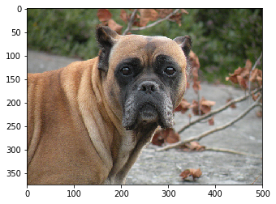

```
/data/dog_images/train/034.Boxer/Boxer_02411.jpg
```

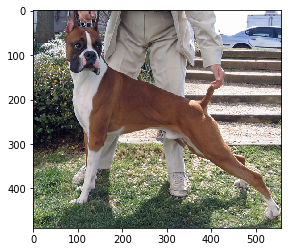

```python
## Testing the Xception_predict_breed
## In this section I tried several pages and
## plotted images to see for my self how good
## is the prediction

#Xception_predict_breed(test_Xception[1])
#img_path = human_files[250]
img_path= test_files[128]
#img_path = 'images/flowers.jpg'
breed, vec = Xception_predict_breed(img_path)
start = breed.find('.')+1
print('image_path is : ', img_path)
print('predicted breed is : ',breed[start:])
print('predicted vector maximum',vec.max(),' median ', np.median(vec))

img = plt.imread(img_path)
fig, ax = plt.subplots()
ax.imshow(img)
plt.show()

breed = breed[start:]
for image_path in train_files:
    if image_path.find(breed) != -1:
        print(image_path)
        img = plt.imread(image_path)
        break


fig, ax = plt.subplots()
ax.imshow(img)
plt.show()
```

## Step 6: Write your Algorithm

Write an algorithm that accepts a file path to an image and first determines whether the image contains a human, dog, or neither. Then,

- if a **dog** is detected in the image, return the predicted breed.
- if a **human** is detected in the image, return the resembling dog breed.
- if **neither** is detected in the image, provide output that indicates an error.

You are welcome to write your own functions for detecting humans and dogs in images, but feel free to use the `face_detector` and `dog_detector` functions developed above. You are **required** to use your CNN from Step 5 to predict dog breed.

Some sample output for our algorithm is provided below, but feel free to design your own user experience!

[figure not shown]

### (IMPLEMENTATION) Write your Algorithm

```
 image object is :  other
```

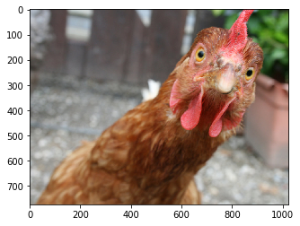

```
photo is neither dog nor human
```

```python
### TODO: Write your algorithm.
### Feel free to use as many code cells as needed.

def plot_image(img_path):
    img = plt.imread(img_path)
    fig, ax = plt.subplots()
    ax.imshow(img)
    plt.show()

def image_type(img_path):
    #breed, vec = Xception_predict_breed(img_path)
    breed = stack_model_breed_detector(img_path)
    start = breed.find('.')+1
    if dog_detector(img_path):
        img_object = 'dog'
    elif face_detector(img_path):
        img_object = 'human'
    else:
        img_object = 'other'
    return img_object

def image_message(img_path):
    #breed, vec = Xception_predict_breed(img_path)
    breed = stack_model_breed_detector(img_path)
    start = breed.find('.')+1
    img_obj = image_type(img_path)
    print('\n image object is : ', img_obj,)
    plot_image(img_path)
    if img_obj == 'dog':
        print('dog shows up in the photo')
        print('the predicted dog breed is', breed[start:-1],'\n' )
    elif img_obj == 'human':
        print('human face appears in the photo')
        print('the closest dog breed with similar looks is ...')
        print('+++',breed[start:-1],'+++', '\n')
    else:
        print('photo is neither dog nor human \n')


#img_path = human_files[3333]
img_path = 'images/chicken-011.jpg'
#print('image object is: ', image_type(img_path))
image_message(img_path)
```

## Step 7: Test Your Algorithm

In this section, you will take your new algorithm for a spin! What kind of dog does the algorithm think that **you** look like? If you have a dog, does it predict your dog's breed accurately? If you have a cat, does it mistakenly think that your cat is a dog?

### (IMPLEMENTATION) Test Your Algorithm on Sample Images!

Test your algorithm at least six images on your computer. Feel free to use any images you like. Use at least two human and two dog images.

**Question 6:** Is the output better than you expected :) ? Or worse :( ? Provide at least three possible points of improvement for your algorithm.

**Answer:** the output better than expected. Since the algorithm is determined by accuracy of the face and dog detectors the improvements would be:

- improve human face detection algorithm.
- if human face is the object, show an image of the corresponding dog breed
- improve dog breed detection. I used stacked model which the best that I got, its time consuming to run the three pre-trained models especially loading the bottleneck features. I wonder whether the extra 3% increase in accuracy is worth it.
- use image augmentation which I avoided here due to time and space consideration.

```
 Test image one :

 image object is :  dog
```

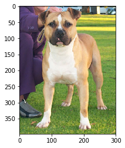

```
dog shows up in the photo
the predicted dog breed is American_staffordshire_terrie


 Test image two :

 image object is :  dog
```

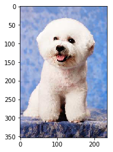

```
dog shows up in the photo
the predicted dog breed is Bichon_fris


 Test image three :

 image object is :  human
```

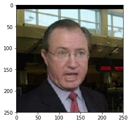

```
human face appears in the photo
the closest dog breed with similar looks is ...
+++ Dachshun +++


 Test image four :

 image object is :  human
```

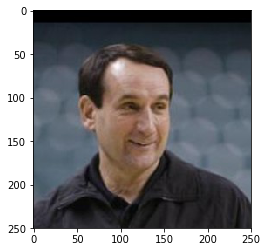

```
human face appears in the photo
the closest dog breed with similar looks is ...
+++ Dachshun +++


 Test image five :

 image object is :  other
```

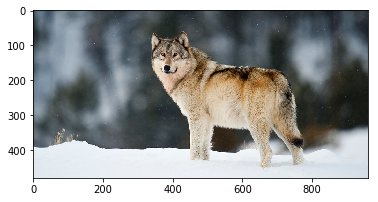

```
photo is neither dog nor human


 Test image six :

 image object is :  other
```

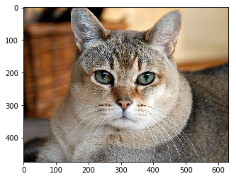

```
photo is neither dog nor human


 Test image seven :

 image object is :  human
```

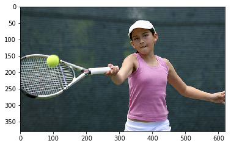

```
human face appears in the photo
the closest dog breed with similar looks is ...
+++ Dachshun +++


 image object is :  other
```

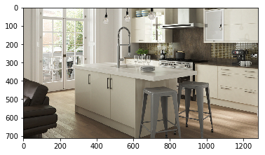

```
photo is neither dog nor human
```

```python
## TODO: Execute your algorithm from Step 6 on
## at least 6 images on your computer.
## Feel free to use as many code cells as needed.

print('\n Test image one :')
img_path = test_files[100]
image_message(img_path)
print('\n Test image two :')
img_path = test_files[589]
image_message(img_path)
print('\n Test image three :')
img_path = human_files[30]
image_message(img_path)
print('\n Test image four :')
img_path = human_files[1090]
image_message(img_path)
print('\n Test image five :')
img_path = 'images/gray-wolf.png'
image_message(img_path)
print('\n Test image six :')
img_path = 'images/cat1.jpg'
image_message(img_path)
#img_path = 'images/red-maine-coon.jpg'
print('\n Test image seven :')
img_path = 'images/Tennis_player.jpg'
image_message(img_path)
#img_path = 'images/Eurasian_wolf.JPG'
img_path = 'images/kitchen.jpg'
image_message(img_path)
#img_path = 'images/flowers.png'
#image_message(img_path)
#img_path = 'images/chicken2.jpg'
#img_path = 'images/chicken-011.jpg'
#image_message(img_path)
#img_path = 'images/Ghatam.jpg'
#img_path = 'images/KPbridge.jpg'
#img_path = 'images/CBD_arthritis.jpg'
#image_message(img_path)
```

# Please download your notebook to submit

In order to submit, please do the following:

1. Download an HTML version of the notebook to your computer using 'File: Download as...'
2. Click on the orange Jupyter circle on the top left of the workspace.
3. Navigate into the dog-project folder to ensure that you are using the provided dog_images, lfw, and bottleneck_features folders; this means that those folders will *not* appear in the dog-project folder. If they do appear because you downloaded them, delete them.
4. While in the dog-project folder, upload the HTML version of this notebook you just downloaded. The upload button is on the top right.
5. Navigate back to the home folder by clicking on the two dots next to the folder icon, and then open up a terminal under the 'new' tab on the top right
6. Zip the dog-project folder with the following command in the terminal: `zip -r dog-project.zip dog-project`
7. Download the zip file by clicking on the square next to it and selecting 'download'. This will be the zip file you turn in on the next node after this workspace!